# Simple Linear Regression using R

Yue Jin  
Feb 15 2017

### What is Simple Linear Regression

Simple linear regression is an approach for modeling the **relationship** between a response variable, denoted y and a predictor variable, denoted x.

- Continuous variable
- Only one predictor variable is used
- Examples: height and weight; sales and advertising dollars; GDP and Personal Expenditure

### Relationship between Two Economic Accounts

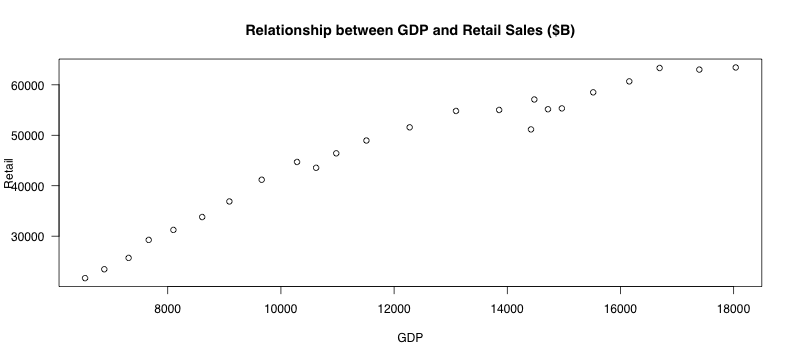

### Basic Model

True Model

- \( {y_i} \) = \( {\beta}_0 \) + \( {\beta}_1{x_i} \)

Best fitting line

- \( \hat{y_i} \) = \( \hat{\beta}_0 \)+ \( \hat{\beta}_1{x_i} \)
- \( {y_i} \)- \( \hat{y_i} \) = \( {\epsilon_i} \)
- \( {\beta}_0 \) and \( {\beta}_1 \) are called coefficient, \( {\epsilon_i} \) is called prediction/residual error

### Finding the Best Fitting Line

A line that fits the data best will be one for which the **overall** prediction errors are as small as possible. One way to achieve this goal is to through minimizing the sum of the squared prediction errors.  
\[ Q = \sum_{i=1}^n ({y_i}- \hat{y_i})^2 \]

### How to do it in R?

```r
head(data,2)
```

```
  Year    GDP   Retail
1 1992 6539.3 21685.15
2 1993 6878.7 23446.16
```

```r
fit<-lm(data$Retail~data$GDP); fit
```

```
Call:
lm(formula = data$Retail ~ data$GDP)

Coefficients:
(Intercept)     data$GDP
   3058.581        3.609
```

### Overview of our model

```r
summary(fit)
```

```
Call:
lm(formula = data$Retail ~ data$GDP)

Residuals:
    Min      1Q  Median      3Q     Max
-4977.0 -2011.8  -447.9  2430.9  4528.7

Coefficients:
             Estimate Std. Error t value Pr(>|t|)
(Intercept) 3058.5810  2350.3683   1.301    0.207
data$GDP       3.6095     0.1875  19.247 2.97e-15 ***
---
Signif. codes:  0 '***' 0.001 '**' 0.01 '*' 0.05 '.' 0.1 ' ' 1

Residual standard error: 3214 on 22 degrees of freedom
Multiple R-squared:  0.9439,    Adjusted R-squared:  0.9414
F-statistic: 370.5 on 1 and 22 DF,  p-value: 2.966e-15
```

### Assumptions of Simple Linear Regression

- Linear relationship between response variable and predictor variable
- The errors, \( {\epsilon_i} \), at each value of predictor, are independent
- \( {\epsilon_i} \) are normally distributed.
- \( {\epsilon_i} \) identically distributed, i.e. have equal variance

### Linearity Diagnostics

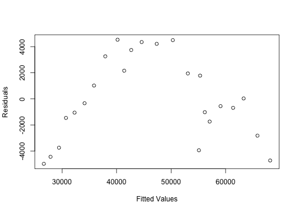

```r
plot(fit$residuals~fit$fitted,xlab="Fitted Values",ylab="Residuals")
```

- If the residual does not have pattern across predictors, the relationship between two variables is believed to be linear.

### Error Independence Diagnostics

```r
library(car)
durbinWatsonTest(fit$residuals)
```

```
[1] 0.2868387
```

The Durbin-Watson statistic tests autocorrelation. It is always between 0 and 4. A value of **2** means that there is no autocorrelation in the sample. Values approaching **0** indicate positive autocorrelation and values toward **4** indicate negative autocorrelation.

### Error Normality Diagnostics

A qq plot is a plot of the **quantiles** of the a data set against the quantiles of the other data set. If the plotted points fall closely onto the identity line, the data is believed to come from the normal distribution.

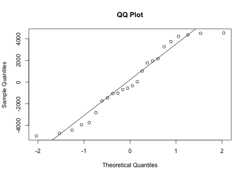

```r
qqnorm(fit$residuals, main="QQ Plot")
qqline(fit$residuals)
```

### Error Equal Variance Dignostics

If the spread-level plot displays a straight line. It means there's no heteroskedasticity.

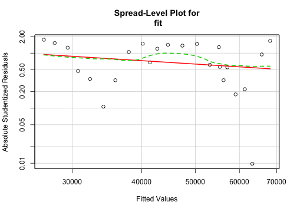

```
Suggested power transformation:  1.638284
```

```r
spreadLevelPlot(fit)
```

### How Good is Our model?

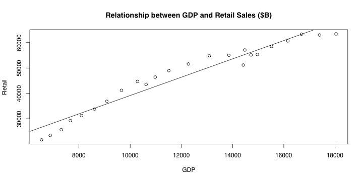

```r
plot(data$Retail~data$GDP,data,type="p",main="Relationship between GDP and Retail Sales ($B)",cex=1,cex.axis=1,family="sans",ylab="Retail",xlab="GDP")
abline(a=fit$coef[1],b=fit$coef[2])
```

### A bit about Multivariate Linear Regression

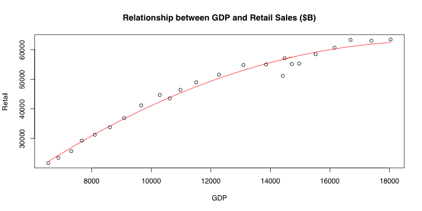

```r
plot(data$Retail~data$GDP,data,type="p",main="Relationship between GDP and Retail Sales ($B)",cex=1,cex.axis=1,family="sans",ylab="Retail",xlab="GDP")
x2<-(data$GDP)^2
fit2<-lm(data$Retail~data$GDP+x2)
lines(data$GDP,fit2$fitted,col=2)
```